# 1. La norme

- CapiTainS a pour objectif de rendre un texte disponible à la citation à travers une série de petites règles que doivent suivre les documents
- Suite d’outils et une norme
- Source du cours : https://github.com/Capitains/DH2016

# 2. Les identifiants

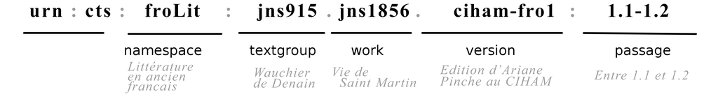

Norme basée sur identifiant CTS

# 3. La structure des dossiers

- Un dossier corpus avec un sous dossier data
- Un dossier avec l’identifiant du textgroup
  - et un fichier **cts**.xml pour les métadonnées
- Un dossier avec l’identifiant work
  - et un fichier **cts**.xml pour les métadonnées
  - et les fichiers d’éditions, de traductions et de commentaire

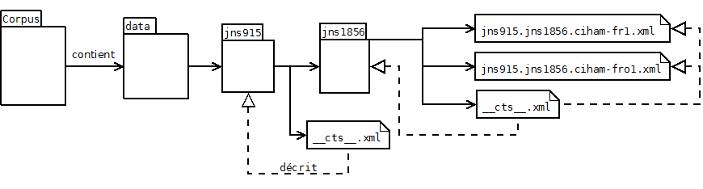

Structure

# 4. Métadonnées du textgroup

```xml
<textgroup xmlns="http://chs.harvard.edu/xmlns/cts"
              urn="urn:cts:froLit:jns915">
                <groupname xml:lang="fre">Wauchier de Denain</groupname>
            </textgroup>
```

# 5. Métadonnées du work et de l’édition

https://en.wikipedia.org/wiki/ISO_639:f

```xml
<work xmlns="http://chs.harvard.edu/xmlns/cts"
                groupUrn="urn:cts:froLit:jns915"
                urn="urn:cts:froLit:jns915.jns1856" xml:lang="fro">
                <title xml:lang="fre">Vie de Saint Martin</title>
                <edition workUrn="urn:cts:froLit:jns915.jns1856" urn="urn:cts:froLit:jns915.jns1856.ciham-fro1" xml:lang="fro">
                    <label xml:lang="fre">Vie de Saint Martin</label>
                    <description xml:lang="fre">Édition du CIHAM basé sur le manuscrit de la BNF FR411 par Ariane Pinche</description>
                </edition>
            </work>
```

# 5 bis Métadonnées avancées :

```xml
<textgroup xmlns="http://chs.harvard.edu/xmlns/cts"
                    xmlns:cpt="http://purl.org/capitains/ns/1.0#"
                    xmlns:saws="http://purl.org/saws/ontology#"
                    xmlns:dc="http://purl.org/dc/elements/1.1/"
                    xmlns:dct="http://purl.org/dc/terms/"
                    xmlns:schema="http://schema.org/"
                    urn="urn:cts:froLit:jns915">
              <groupname xml:lang="fre">Wauchier de Denain</groupname>
              <cpt:structured-metadata>
                <dc:type>schema:Person</dc:type>
                <schema:birthDate>1200</schema:birthDate>
                <schema:deathDate>1299</schema:deathDate>
                <dc:description>Wauchier de Denain est un écrivain français de langue d'oïl et traducteur actif au début du XIIIe siècle. On lui attribue notamment une continuation du Graal de Chrétien de Troyes. [https://fr.wikipedia.org/wiki/Wauchier_de_Denain]</dc:description>
                <dc:identifier>https://www.wikidata.org/wiki/Q942529</dc:identifier>
              </cpt:structured-metadata>
            </textgroup>
```

# 6. Un essai de groupe

Un textgroup pour Perceval - http://atilf.atilf.fr/gsouvay/dect/download/Perceval.xml

# 7. Tester

- https://capitains-validator.herokuapp.com/
- Pour ceux-lles avec Python3 sur leur ordinateur (Ne fonctionne pas sous windows) :
  - Installer HookTest : `sudo pip3 install HookTest`
  - Dans le dossier du corpus, ouvrir un terminal et lancer `hooktest --console table --scheme tei --verbose 10 .`

# 8. Le fichier texte TEI : l’identifiant

- On mets l’identifiant du texte dans l’attribut @n de
  - `/TEI/text/body` pour de la TEI normale
  - `TEI/text/body/div[@type="edition" or @type="translation" or @type="commentary"]` pour de l’epidoc
- On met sur ce même tag l’attribut xml:lang avec le code en trois caractères

# 9. Le fichier texte TEI : l’identification des passages

```xml
<refsDecl n="CTS">
              <cRefPattern
                  n="vers" matchPattern="(\w+).(\w+)"
                  replacementPattern="#xpath(/tei:TEI/tei:text/tei:body/tei:div/tei:div[@n='$1']/tei:l[@n='$2'])">
                  <p>Ce pointeur extrait les vers des poèmes</p>
              </cRefPattern>
              <cRefPattern
                  n="poeme" matchPattern="(\w+)"
                  replacementPattern="#xpath(/tei:TEI/tei:text/tei:body/tei:div/tei:div[@n='$1'])">
                  <p>Ce pointeur extrait les poèmes</p>
              </cRefPattern>
            </refsDecl>
```

# Exemple

- Source : http://atilf.atilf.fr/gsouvay/dect/download/Perceval.xml http://www.atilf.fr/dect/